# Time Series Interpolation Algorithms: Part 2

Melissa Van Bussel  
March 25th, 2019

### Recall from last time...

- A *time series* is a sequence of observations, \( \{X_t\} \),  
  one taken at each time \( t \) and arranged in chronological order
- There are many methods available for modelling “nice” time series
- But…our data is not always nice

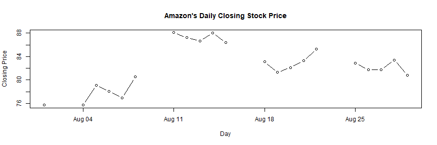

### Goals of this Honours Project

- Research a variety of interpolation algorithms
- Test the algorithms on real-world data
- Evaluate the performance of the algorithms using a number of performance criteria

### So...what would you do?

- Let's brainstorm!
- Consider the following example, which we will use for the next few slides: \[ \{X_t\} = \{4, 7, 9, \text{NA, NA}, 6, 3, 5, \text{NA}, 12, 15\} \]
- How would you fill in those points?

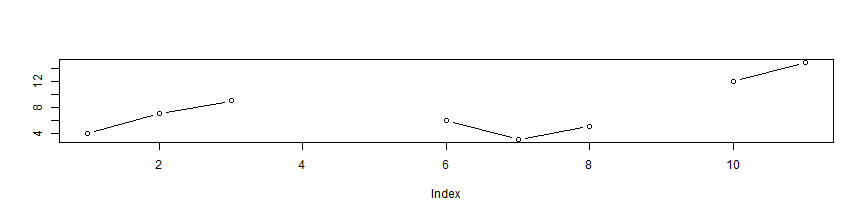

### Some Notation

- We denote \( x \) as the original time series, and \( X \) as the time series after the missing points have been interpolated
- There are many different algorithms; we will discuss a handful of them, briefly

### Some Terrible Methods

\[ \{X_t\} = \{4, 7, 9, \text{NA, NA}, 6, 3, 5, \text{NA}, 12, 15\} \]

- Replace all missing values with a randomly generated number between the minimum value and maximum value of the series
- Replace all missing values with the mean of the non-missing values (or median, or mode)

### Slightly less terrible, but still terrible...

\[ \{X_t\} = \{4, 7, 9, \text{NA, NA}, 6, 3, 5, \text{NA}, 12, 15\} \]

- Last Observation Carried Forward
- Next Observation Carried Backward
- Nearest Neighbor

\[ X_i = \begin{cases} x_A & i < \frac{a+b}{2} \\ x_B & \text{otherwise} \\ \end{cases} \]

### Linear Interpolation

- Let \( x \) be the original time series. Let \( X \) be the series after interpolation. Then the linear interpolation algorithm is as follows: \[ X_i = \frac{x_A - x_B}{a -b}(i - b) + x_B \]

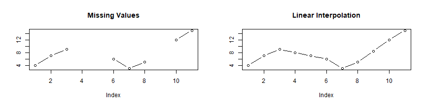

### Cubic Splines

- For those of you that have taken 3180, this might be familiar!
- Cubic splines are interpolating polynomials
- Continuous cubic function connecting the endpoints of each sub-interval (piecewise defined)
- There are different “flavours” of cubic splines, based on boundary conditions

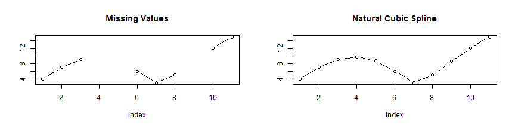

### Kalman Filters

- The Kalman Filter is also sometimes known as the LQE Algorithm
- Step 1: Prediction step (estimates, with their uncertainties)
- Step 2: Update step (outcome of next observation measured; higher certainty = higher weights)
- Apollo navigation computer

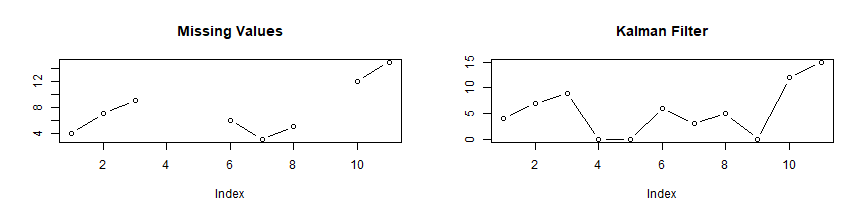

### Moving Averages

- A “window” is created around the missing value, and a weighted average is computed
- Simple, Linear Weighted, Exponential Weighted
- Points which are closer to the missing observation are weighted more heavily

\[ \{X_t\} = \{4, 7, 9, \text{NA, NA}, 6, 3, 5, \text{NA}, 12, 15\} \]

### Moving Averages

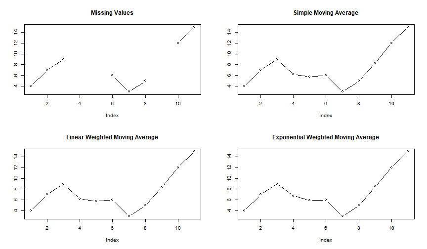

### Hybrid Wiener Interpolator

- An interpolator invented by our very own Wesley Burr!

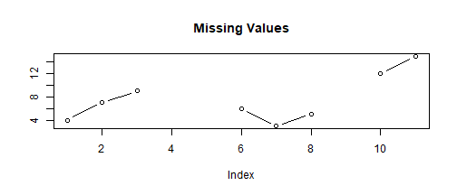

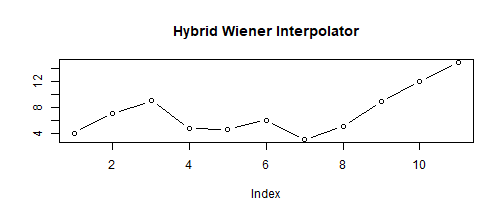

### How can we evaluate the performance?

- Now that we've seen a handful of algorithms, we need a way to see how well they perform.
- \( r, r^2 \), absolute differences, MBE, ME, MAE, MRE, MARE, MAPE, SSE, MSE, RMS, NMSE, RMSE, NRMSD, RMSS…to name a few.
- Let's focus on a couple.

### Coefficient of Correlation

- How closely related are \( x \) and \( X \)?
- Ranges from -1 to +1, where +1 represents a perfectly positive correlation and -1 represents a perfectly negative correlation

\[ r = \frac{\sum_{i = 1}^n(X_i - \bar{X})(x_i - \bar{x})}{\sqrt{\sum_{i=1}^n(X_i - \bar{X})^2} \sqrt{\sum_{i=1}^n(x_i - \bar{x})^2}} \]

### Mean Square Error

- Commonly referred to as MSE
- The sum of the squared errors, scaled by \( n \):

\[ \mathbf{MSE} = \frac{1}{n} \sum_{i = 1}^n (X_i - x_i)^2 \]

### Testing Out the Algorithms

- 5%, 10%, 15%, 20%, 25% gaps imposed on 3 real-world datasets (no missing observations originally)
- 18 different interpolation algorithms used on each one
- 17 performance criteria for each
- Created tables which display the algorithms that performed BEST, for each of the 17 criteria, for each of the algorithms and datasets
- Created tables which display the algorithms that performed WORST for each of the 17 criteria, for each of the algorithms and datasets

### The Datasets Used

- The `airquality` dataset, temperature variable
- Daily measurements of temperature (in Fahrenheit) in New York, May to September 1973

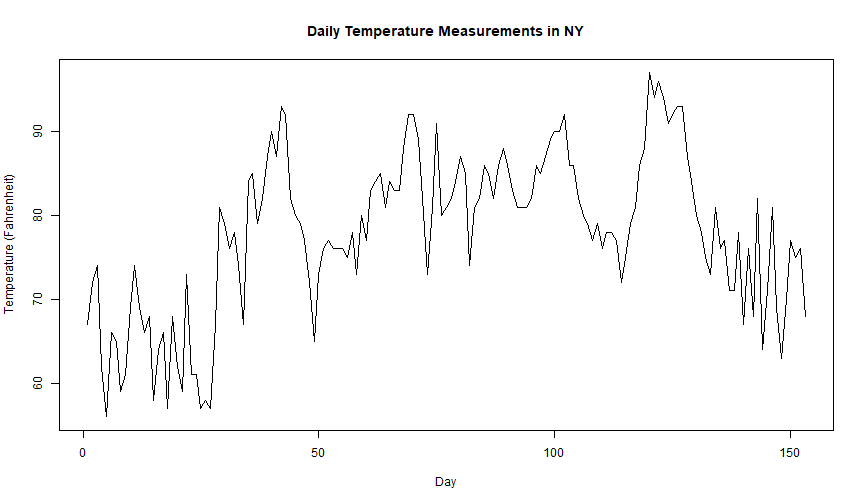

### The Datasets Used

- The `sunspots` dataset
- Monthly mean relative sunspot numbers from 1749 to 1983

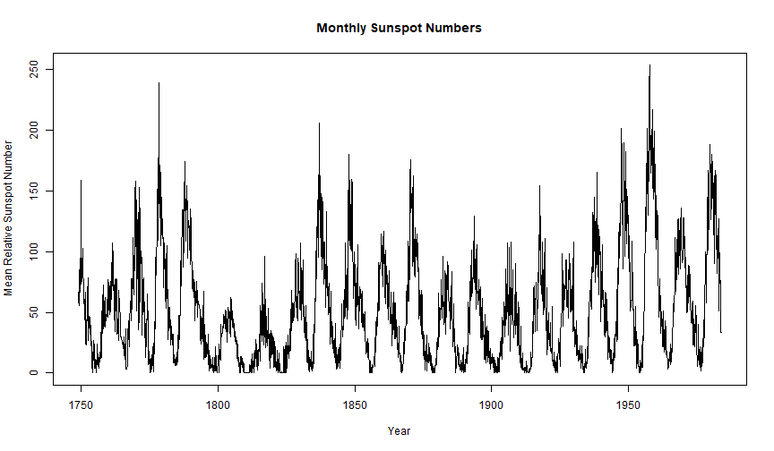

### The Datasets Used

- The `flux` dataset, Penticton
- Daily noon solar flux measurements from Penticton, British Columbia

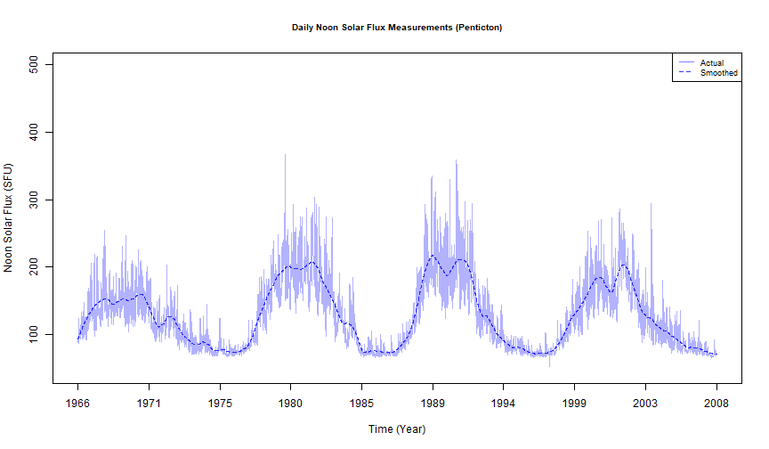

### Why these datasets?

- Datasets are of varying length
- Time intervals are varying
- Non-Stationary
- And, being honest…my computer couldn't handle much more.

### Discussion of Results

- Some criteria (such as MBE) are ineffective / not useful
- Replacing missing values with random numbers, means, medians, or modes is a terrible idea (as expected)
- Exponential Weighted Moving Average and Kalman Filters performed particularly well
- The algorithms which performed well performed VERY well, and it was a close race
- Different time series

### Next Steps

- Expand analysis to include more datasets (will require more computational power)
- Experiment with varying gap lengths
- Include datasets from a wide variety of fields